# Tugas-Pertemuan-2

Rafi Adabhi Sunarya

2025-08-30

# Library

```r
library("forecast")
```

```r
library("graphics")
library("TTR")
library("TSA")
library(rio)
library(ggplot2)
```

# Impor Data

```r
data1 <- read.csv("D:\\Github\\MPDW\\Pertemuan 1\\crude_oil_filtered_255_382.csv")

data1
```

```
##     periode  price
## 1       255  39.88
## 2       256  37.05
## 3       257  43.80
## 4       258  42.12
## 5       259  49.64
## 6       260  51.76
## 7       261  49.13
## 8       262  43.45
## 9       263  48.20
## 10      264  51.75
## 11      265  55.40
## 12      266  49.72
## 13      267  51.97
## 14      268  56.50
```

[output cut: 114 more lines]

# Eksplorasi Data

```r
View(data1)
str(data1)
```

```
## 'data.frame':    128 obs. of  2 variables:
##  $ periode: int  255 256 257 258 259 260 261 262 263 264 ...
##  $ price  : num  39.9 37 43.8 42.1 49.6 ...
```

```r
dim(data1)
```

```
## [1] 128   2
```

### Mengubah data agar terbaca sebagai data deret waktu dengan fungsi ts()

```r
data1.ts <- ts(data1$price)
data1.ts
```

```
## Time Series:
## Start = 1
## End = 128
## Frequency = 1
##   [1]  39.88  37.05  43.80  42.12  49.64  51.76  49.13  43.45  48.20  51.75
##  [11]  55.40  49.72  51.97  56.50  60.57  68.94  66.24  59.76  57.32  61.04
##  [21]  67.92  61.41  66.63  71.88  71.29  73.93  74.40  70.26  62.91  58.73
##  [31]  63.13  61.05  58.14  61.79  65.87  65.71  64.01  70.68  78.21  74.04
##  [41]  81.66  94.53  88.71  95.98  91.75 101.84 101.58 113.46 127.35 140.00
##  [51] 124.08 115.46 100.64  67.81  54.43  44.60  41.68  44.76  49.66  51.12
##  [61]  66.31  69.89  69.45  69.96  70.61  77.00  77.28  79.36  72.89  79.66
##  [71]  83.76  86.15  73.97  75.63  78.95  71.92  79.97  81.43  84.11  91.38
##  [81]  92.19  96.97 106.72 113.93 102.70  95.42  95.70  88.81  79.20  93.19
##  [91] 100.36  98.83  98.48 107.07 103.02 104.87  86.53  84.96  88.06  96.47
## [101]  92.19  86.24  88.91  91.82  97.49  92.05  97.23  93.46  91.97  96.56
## [111] 105.03 107.65 102.33  96.38  92.72  98.42  97.49 102.59 101.58  99.74
## [121] 102.71 105.37  98.17  95.96  91.16  80.54  66.15  53.27
```

```r
summary(data1.ts)
```

```
##    Min. 1st Qu.  Median    Mean 3rd Qu.    Max.
##   37.05   63.79   79.81   79.81   96.49  140.00
```

### Membuat plot data deret waktu

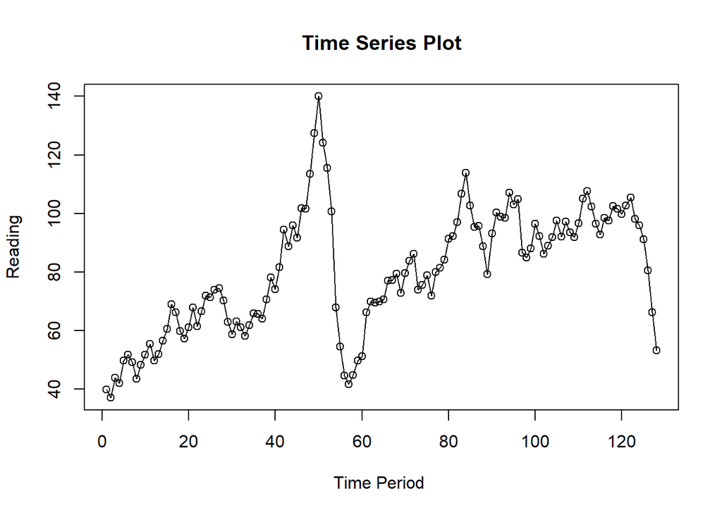

```r
ts.plot(data1.ts, xlab="Time Period ", ylab="Reading",
        main = "Time Series Plot")
points(data1.ts)
```

# Single Moving Average & Double Moving Average

### Pembagian Data

```r
# hitung jumlah data
n <- nrow(data1)

# tentukan batas 80%
n_train <- floor(0.8 * n)

# bagi data
training_ma <- data1[1:n_train, ]
testing_ma  <- data1[(n_train+1):n, ]

# ubah ke time series
train_ma.ts <- ts(training_ma$price)
test_ma.ts  <- ts(testing_ma$price)
```

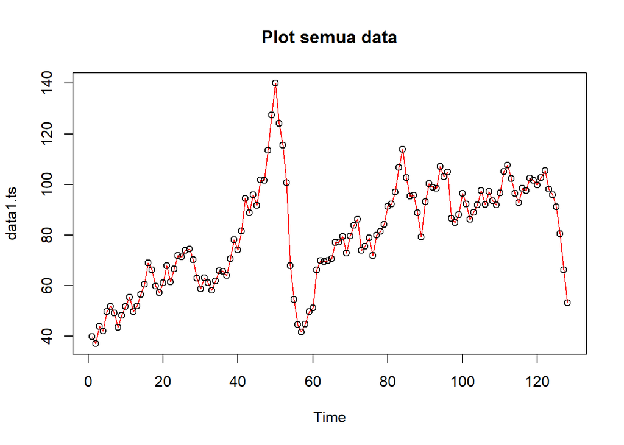

```r
#eksplorasi keseluruhan data
plot(data1.ts, col="red",main="Plot semua data")
points(data1.ts)
```

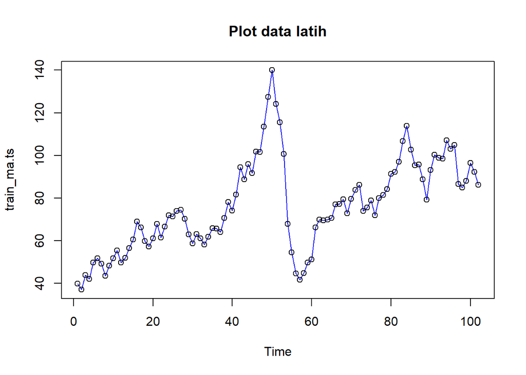

```r
#eksplorasi data latih
plot(train_ma.ts, col="blue",main="Plot data latih")
points(train_ma.ts)
```

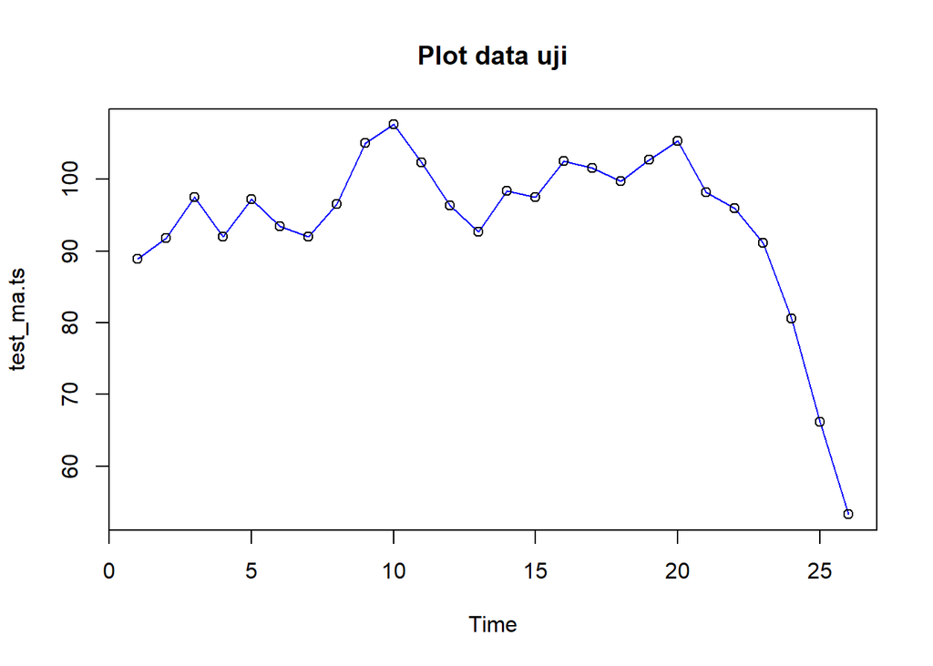

```r
#eksplorasi data uji
plot(test_ma.ts, col="blue",main="Plot data uji")
points(test_ma.ts)
```

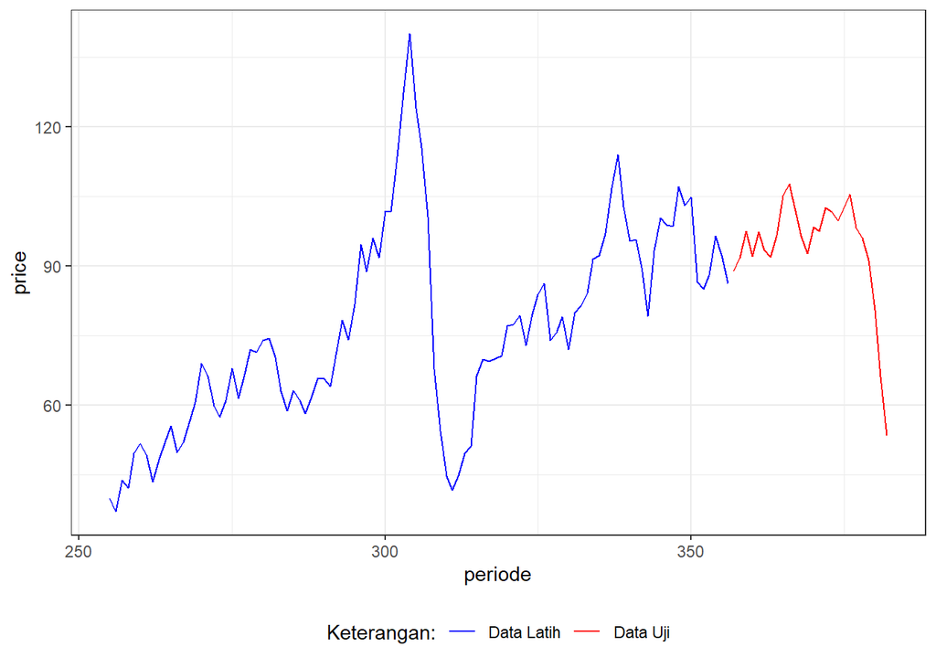

```r
ggplot() +
  geom_line(data = training_ma, aes(x = periode, y = price, col = "Data Latih")) +
  geom_line(data = testing_ma, aes(x = periode, y = price, col = "Data Uji")) +
  labs(x = "periode", y = "price", color = "Legend") +
   scale_colour_manual(name="Keterangan:", breaks = c("Data Latih", "Data Uji"),
                      values = c("blue", "red")) +
  theme_bw() + theme(legend.position = "bottom",
                     plot.caption = element_text(hjust=0.5, size=12))
```

## Single Moving Average (SMA)

```r
data.sma<-SMA(train_ma.ts, n=4)
data.sma
```

```
## Time Series:
## Start = 1
## End = 102
## Frequency = 1
##   [1]       NA       NA       NA  40.7125  43.1525  46.8300  48.1625  48.4950
##   [9]  48.1350  48.1325  49.7000  51.2675  52.2100  53.3975  54.6900  59.4950
##  [17]  63.0625  63.8775  63.0650  61.0900  61.5100  61.9225  64.2500  66.9600
##  [25]  67.8025  70.9325  72.8750  72.4700  70.3750  66.5750  63.7575  61.4550
##  [33]  60.2625  61.0275  61.7125  62.8775  64.3450  66.5675  69.6525  71.7350
##  [41]  76.1475  82.1100  84.7350  90.2200  92.7425  94.5700  97.7875 102.1575
##  [49] 111.0575 120.5975 126.2225 126.7225 120.0450 101.9975  84.5850  66.8700
##  [57]  52.1300  46.3675  45.1750  46.8050  52.9625  59.2450  64.1925  68.9025
##  [65]  69.9775  71.7550  73.7125  76.0625  76.6325  77.2975  78.9175  80.6150
##  [73]  80.8850  79.8775  78.6750  75.1175  76.6175  78.0675  79.3575  84.2225
##  [81]  87.2775  91.1625  96.8150 102.4525 105.0800 104.6925 101.9375  95.6575
##  [89]  89.7825  89.2250  90.3900  92.8950  97.7150 101.1850 101.8500 103.3600
##  [97] 100.3725  94.8450  91.1050  89.0050  90.4200  90.7400
```

Data pemulusan pada periode ke-t selanjutnya digunakan sebagai nilai peramalan pada periode ke t+1 sehingga hasil peramalan 1 periode kedepan adalah sebagai berikut.

```r
data.ramal<-c(NA,data.sma)
data.ramal #forecast 1 periode ke depan
```

```
##   [1]       NA       NA       NA       NA  40.7125  43.1525  46.8300  48.1625
##   [9]  48.4950  48.1350  48.1325  49.7000  51.2675  52.2100  53.3975  54.6900
##  [17]  59.4950  63.0625  63.8775  63.0650  61.0900  61.5100  61.9225  64.2500
##  [25]  66.9600  67.8025  70.9325  72.8750  72.4700  70.3750  66.5750  63.7575
##  [33]  61.4550  60.2625  61.0275  61.7125  62.8775  64.3450  66.5675  69.6525
##  [41]  71.7350  76.1475  82.1100  84.7350  90.2200  92.7425  94.5700  97.7875
##  [49] 102.1575 111.0575 120.5975 126.2225 126.7225 120.0450 101.9975  84.5850
##  [57]  66.8700  52.1300  46.3675  45.1750  46.8050  52.9625  59.2450  64.1925
##  [65]  68.9025  69.9775  71.7550  73.7125  76.0625  76.6325  77.2975  78.9175
##  [73]  80.6150  80.8850  79.8775  78.6750  75.1175  76.6175  78.0675  79.3575
##  [81]  84.2225  87.2775  91.1625  96.8150 102.4525 105.0800 104.6925 101.9375
##  [89]  95.6575  89.7825  89.2250  90.3900  92.8950  97.7150 101.1850 101.8500
##  [97] 103.3600 100.3725  94.8450  91.1050  89.0050  90.4200  90.7400
```

```r
data.gab<-cbind(
  aktual=c(data1.ts),
  pemulusan=c(data.sma,rep(NA,26)),
  ramalan=c(data.ramal,rep(data.ramal[length(data.ramal)],25)))

data.gab #forecast 26 periode ke depan
```

```
##        aktual pemulusan  ramalan
##   [1,]  39.88        NA       NA
##   [2,]  37.05        NA       NA
##   [3,]  43.80        NA       NA
##   [4,]  42.12   40.7125       NA
##   [5,]  49.64   43.1525  40.7125
##   [6,]  51.76   46.8300  43.1525
##   [7,]  49.13   48.1625  46.8300
##   [8,]  43.45   48.4950  48.1625
##   [9,]  48.20   48.1350  48.4950
##  [10,]  51.75   48.1325  48.1350
##  [11,]  55.40   49.7000  48.1325
##  [12,]  49.72   51.2675  49.7000
##  [13,]  51.97   52.2100  51.2675
##  [14,]  56.50   53.3975  52.2100
```

[output cut: 114 more lines]

Adapun plot data deret waktu dari hasil peramalan yang dilakukan adalah sebagai berikut.

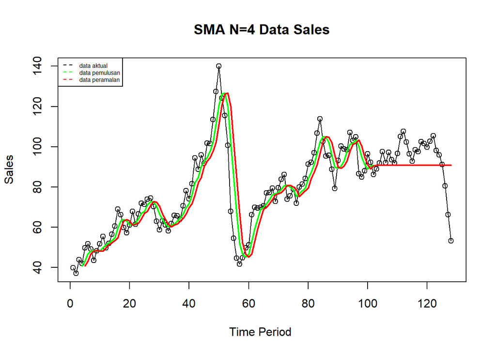

```r
ts.plot(data1.ts, xlab="Time Period ", ylab="Sales", main= "SMA N=4 Data Sales")
points(data1.ts)
lines(data.gab[,2],col="green",lwd=2)
lines(data.gab[,3],col="red",lwd=2)
legend("topleft",c("data aktual","data pemulusan","data peramalan"), lty=8, col=c("black","green","red"), cex=0.5)
```

```r
#Menghitung nilai keakuratan data latih
error_train.sma = train_ma.ts-data.ramal[1:length(train_ma.ts)]

SSE_train.sma = sum(error_train.sma[5:length(train_ma.ts)]^2)
MSE_train.sma = mean(error_train.sma[5:length(train_ma.ts)]^2)
MAPE_train.sma = mean(abs((error_train.sma[5:length(train_ma.ts)]/train_ma.ts[5:length(train_ma.ts)])*100))

akurasi_train.sma <- matrix(c(SSE_train.sma, MSE_train.sma, MAPE_train.sma))
row.names(akurasi_train.sma)<- c("SSE", "MSE", "MAPE")
colnames(akurasi_train.sma) <- c("Akurasi m = 4")
akurasi_train.sma
```

```
##      Akurasi m = 4
## SSE    15562.84607
## MSE      158.80455
## MAPE      12.16205
```

```r
#Menghitung nilai keakuratan data uji
error_test.sma = test_ma.ts-data.gab[103:128,3]

SSE_test.sma = sum(error_test.sma^2)
MSE_test.sma = mean(error_test.sma^2)
MAPE_test.sma = mean(abs((error_test.sma/test_ma.ts*100)))

akurasi_test.sma <- matrix(c(SSE_test.sma, MSE_test.sma, MAPE_test.sma))
row.names(akurasi_test.sma)<- c("SSE", "MSE", "MAPE")
colnames(akurasi_test.sma) <- c("Akurasi m = 4")
akurasi_test.sma
```

```
##      Akurasi m = 4
## SSE     3793.03750
## MSE      145.88606
## MAPE      10.85832
```

MAPE SMA Data latih: 12.16205 Data uji: 10.85832

## Double Moving Average (DMA)

```r
dma <- SMA(data.sma, n = 4)
At <- 2*data.sma - dma
Bt <- 2/(4-1)*(data.sma - dma)
data.dma<- At+Bt
data.ramal1<- c(NA, data.dma)

t = 1:26
f = c()

for (i in t) {
  f[i] = At[length(At)] + Bt[length(Bt)]*(i)
}

data.gab1 <- cbind(aktual = c(data1.ts),
                   pemulusan1 = c(data.sma,rep(NA,26)),
                   pemulusan2 = c(dma, rep(NA,26)),
                   At = c(At, rep(NA,26)),
                   Bt = c(Bt,rep(NA,26)),
                   ramalan = c(data.ramal1, f[-1]))
data.gab1
```

```
##        aktual pemulusan1 pemulusan2        At           Bt   ramalan
##   [1,]  39.88         NA         NA        NA           NA        NA
##   [2,]  37.05         NA         NA        NA           NA        NA
##   [3,]  43.80         NA         NA        NA           NA        NA
##   [4,]  42.12    40.7125         NA        NA           NA        NA
##   [5,]  49.64    43.1525         NA        NA           NA        NA
##   [6,]  51.76    46.8300         NA        NA           NA        NA
##   [7,]  49.13    48.1625   44.71437  51.61062   2.29875000        NA
##   [8,]  43.45    48.4950   46.66000  50.33000   1.22333333  53.90937
##   [9,]  48.20    48.1350   47.90562  48.36437   0.15291667  51.55333
##  [10,]  51.75    48.1325   48.23125  48.03375  -0.06583333  48.51729
##  [11,]  55.40    49.7000   48.61562  50.78438   0.72291667  47.96792
##  [12,]  49.72    51.2675   49.30875  53.22625   1.30583333  51.50729
##  [13,]  51.97    52.2100   50.32750  54.09250   1.25500000  54.53208
##  [14,]  56.50    53.3975   51.64375  55.15125   1.16916667  55.34750
```

[output cut: 114 more lines]

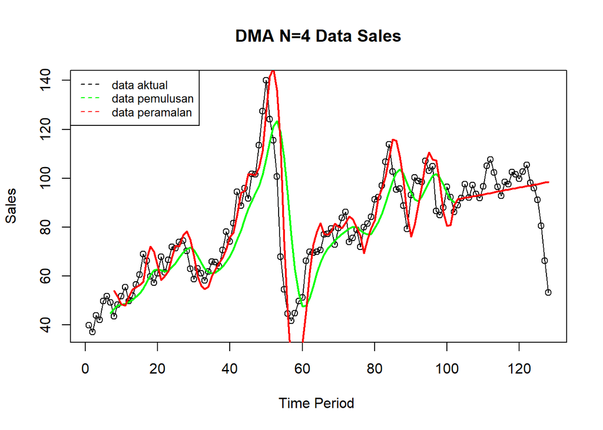

```r
ts.plot(data1.ts, xlab="Time Period ", ylab="Sales", main= "DMA N=4 Data Sales")
points(data1.ts)
lines(data.gab1[,3],col="green",lwd=2)
lines(data.gab1[,6],col="red",lwd=2)
legend("topleft",c("data aktual","data pemulusan","data peramalan"), lty=8, col=c("black","green","red"), cex=0.8)
```

```r
#Menghitung nilai keakuratan data latih DMA
error_train.dma = train_ma.ts-data.ramal1[1:length(train_ma.ts)]

SSE_train.dma = sum(error_train.dma[8:length(train_ma.ts)]^2)
MSE_train.dma = mean(error_train.dma[8:length(train_ma.ts)]^2)
MAPE_train.dma = mean(abs((error_train.dma[8:length(train_ma.ts)]/train_ma.ts[8:length(train_ma.ts)])*100))

akurasi_train.dma <- matrix(c(SSE_train.dma, MSE_train.dma, MAPE_train.dma))
row.names(akurasi_train.dma)<- c("SSE", "MSE", "MAPE")
colnames(akurasi_train.dma) <- c("Akurasi m = 4")
akurasi_train.dma
```

```
##      Akurasi m = 4
## SSE     13785.7896
## MSE       145.1136
## MAPE       11.7706
```

```r
#Menghitung nilai keakuratan data uji DMA
error_test.dma = test_ma.ts-data.gab1[103:128,6]
SSE_test.dma = sum(error_test.dma^2)
MSE_test.dma = mean(error_test.dma^2)
MAPE_test.dma = mean(abs((error_test.dma/test_ma.ts*100)))

akurasi_test.dma <- matrix(c(SSE_test.dma, MSE_test.dma, MAPE_test.dma))
row.names(akurasi_test.dma)<- c("SSE", "MSE", "MAPE")
colnames(akurasi_test.dma) <- c("Akurasi m = 4")
akurasi_test.dma
```

```
##      Akurasi m = 4
## SSE    4096.538262
## MSE     157.559164
## MAPE      9.786481
```

MAPE DMA Data latih : 11.7706 Data uji: 9.786481

# Single Exponential Smoothing & Double Exponential Smoothing

```r
# jumlah baris data
n <- nrow(data1)

# hitung batas 80%
n_train <- floor(0.8 * n)

# bagi data
training <- data1[1:n_train, ]
testing  <- data1[(n_train+1):n, ]

# ubah ke time series
train.ts <- ts(training$price)
test.ts  <- ts(testing$price)
```

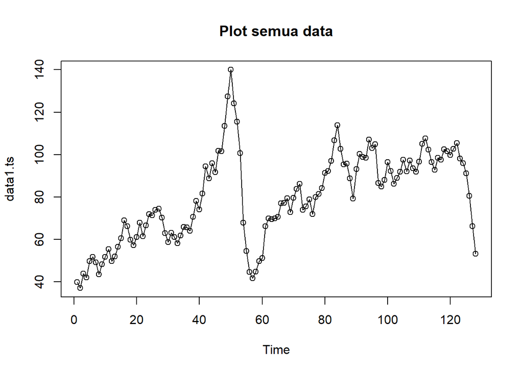

```r
#eksplorasi data
plot(data1.ts, col="black",main="Plot semua data")
points(data1.ts)
```

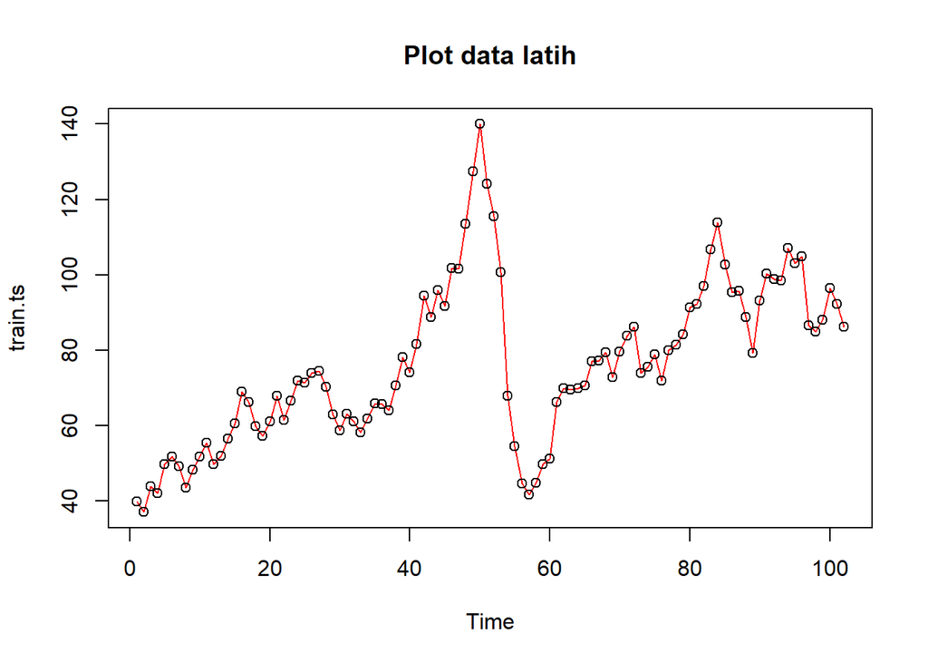

```r
plot(train.ts, col="red",main="Plot data latih")
points(train.ts)
```

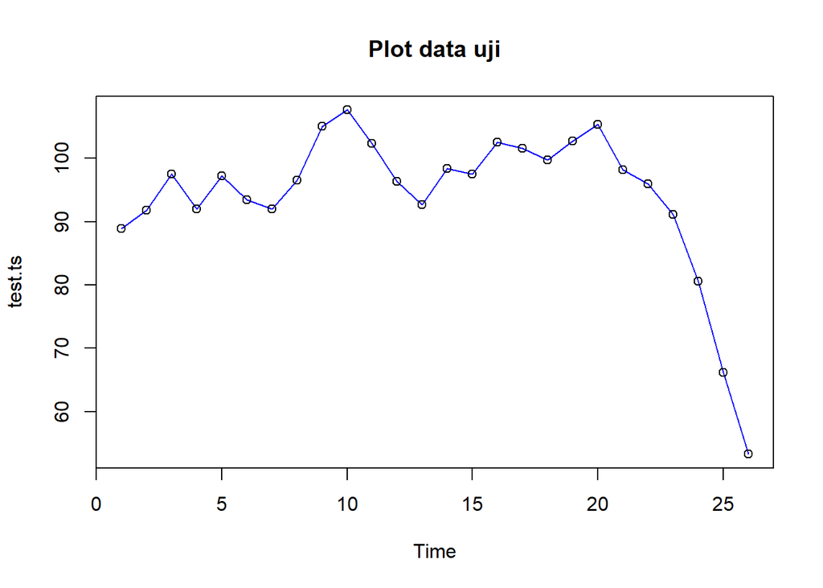

```r
plot(test.ts, col="blue",main="Plot data uji")
points(test.ts)
```

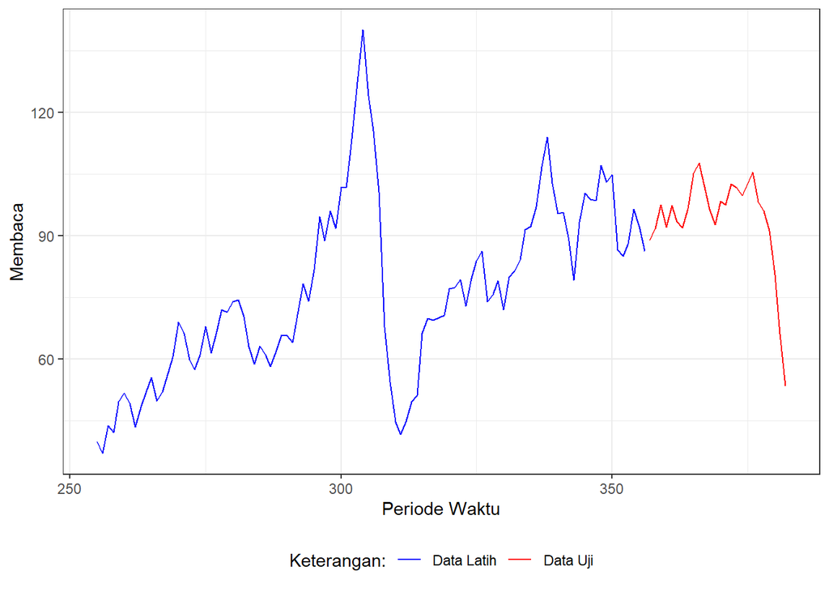

```r
#Eksplorasi dengan GGPLOT
library(ggplot2)
ggplot() +
  geom_line(data = training, aes(x = periode, y = price, col = "Data Latih")) +
  geom_line(data = testing, aes(x = periode, y = price, col = "Data Uji")) +
  labs(x = "Periode Waktu", y = "Membaca", color = "Legend") +
  scale_colour_manual(name="Keterangan:", breaks = c("Data Latih", "Data Uji"),
                      values = c("blue", "red")) +
  theme_bw() + theme(legend.position = "bottom",
                     plot.caption = element_text(hjust=0.5, size=12))
```

## Single Exponential Smoothing

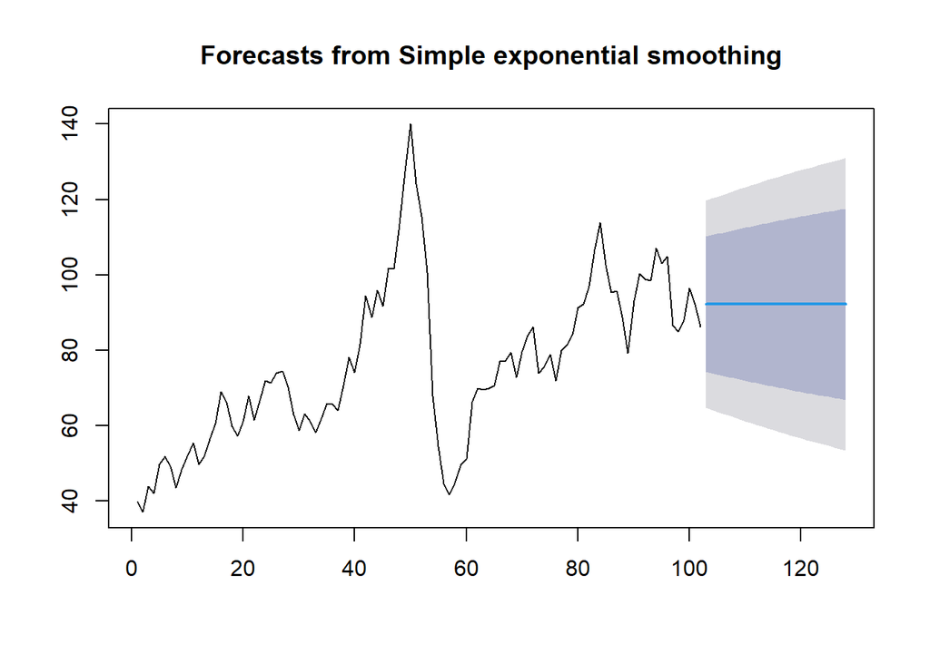

```r
#Cara 1 (fungsi ses)
ses.1 <- ses(train.ts, h = 26, alpha = 0.2)
plot(ses.1)
```

```r
ses.1
```

```
##     Point Forecast    Lo 80    Hi 80    Lo 95    Hi 95
## 103       92.21604 74.27494 110.1571 64.77750 119.6546
## 104       92.21604 73.91964 110.5125 64.23411 120.1980
## 105       92.21604 73.57110 110.8610 63.70107 120.7310
## 106       92.21604 73.22897 111.2031 63.17781 121.2543
## 107       92.21604 72.89289 111.5392 62.66382 121.7683
## 108       92.21604 72.56255 111.8695 62.15862 122.2735
## 109       92.21604 72.23768 112.1944 61.66177 122.7703
## 110       92.21604 71.91800 112.5141 61.17287 123.2592
## 111       92.21604 71.60329 112.8288 60.69155 123.7405
## 112       92.21604 71.29330 113.1388 60.21747 124.2146
## 113       92.21604 70.98785 113.4442 59.75032 124.6818
## 114       92.21604 70.68672 113.7454 59.28979 125.1423
## 115       92.21604 70.38975 114.0423 58.83561 125.5965
## 116       92.21604 70.09677 114.3353 58.38753 126.0446
## 117       92.21604 69.80761 114.6245 57.94531 126.4868
## 118       92.21604 69.52215 114.9099 57.50872 126.9234
## 119       92.21604 69.24022 115.1919 57.07756 127.3545
## 120       92.21604 68.96172 115.4704 56.65162 127.7805
## 121       92.21604 68.68651 115.7456 56.23073 128.2014
## 122       92.21604 68.41448 116.0176 55.81470 128.6174
## 123       92.21604 68.14553 116.2866 55.40337 129.0287
## 124       92.21604 67.87955 116.5525 54.99659 129.4355
## 125       92.21604 67.61644 116.8156 54.59420 129.8379
## 126       92.21604 67.35612 117.0760 54.19608 130.2360
## 127       92.21604 67.09850 117.3336 53.80208 130.6300
## 128       92.21604 66.84349 117.5886 53.41208 131.0200
```

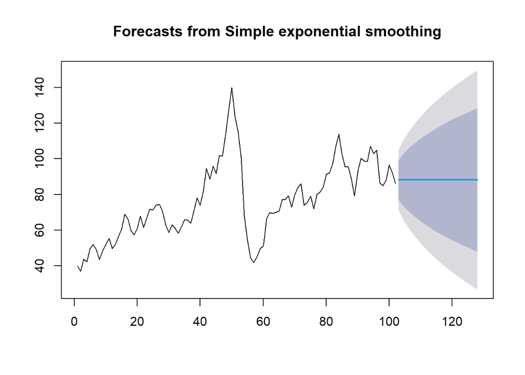

```r
ses.2<- ses(train.ts, h = 26, alpha = 0.7)
plot(ses.2)
```

```r
ses.2
```

```
##     Point Forecast    Lo 80     Hi 80    Lo 95    Hi 95
## 103        88.1749 77.11354  99.23625 71.25802 105.0918
## 104        88.1749 74.67280 101.67700 67.52522 108.8246
## 105        88.1749 72.61019 103.73960 64.37074 111.9791
## 106        88.1749 70.79062 105.55918 61.58794 114.7619
## 107        88.1749 69.14423 107.20557 59.07000 117.2798
## 108        88.1749 67.62935 108.72045 56.75319 119.5966
## 109        88.1749 66.21874 110.13105 54.59585 121.7539
## 110        88.1749 64.89344 111.45635 52.56899 123.7808
## 111        88.1749 63.63963 112.71016 50.65145 125.6983
## 112        88.1749 62.44685 113.90294 48.82724 127.5225
## 113        88.1749 61.30697 115.04283 47.08394 129.2658
## 114        88.1749 60.21351 116.13628 45.41165 130.9381
## 115        88.1749 59.16124 117.18855 43.80234 132.5475
## 116        88.1749 58.14582 118.20397 42.24939 134.1004
## 117        88.1749 57.16363 119.18616 40.74726 135.6025
## 118        88.1749 56.21161 120.13818 39.29127 137.0585
## 119        88.1749 55.28713 121.06266 37.87740 138.4724
## 120        88.1749 54.38794 121.96185 36.50221 139.8476
## 121        88.1749 53.51207 122.83772 35.16268 141.1871
## 122        88.1749 52.65779 123.69200 33.85617 142.4936
## 123        88.1749 51.82359 124.52621 32.58036 143.7694
## 124        88.1749 51.00810 125.34170 31.33318 145.0166
## 125        88.1749 50.21012 126.13967 30.11278 146.2370
## 126        88.1749 49.42857 126.92122 28.91751 147.4323
## 127        88.1749 48.66248 127.68731 27.74588 148.6039
## 128        88.1749 47.91097 128.43882 26.59653 149.7533
```

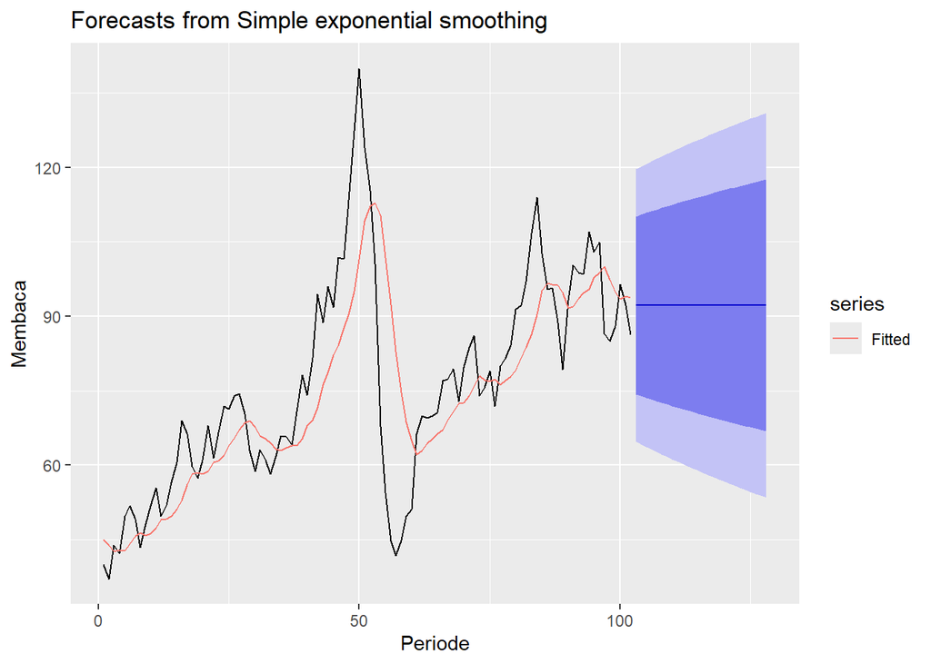

```r
autoplot(ses.1) +
  autolayer(fitted(ses.1), series="Fitted") +
  ylab("Membaca") + xlab("Periode")
```

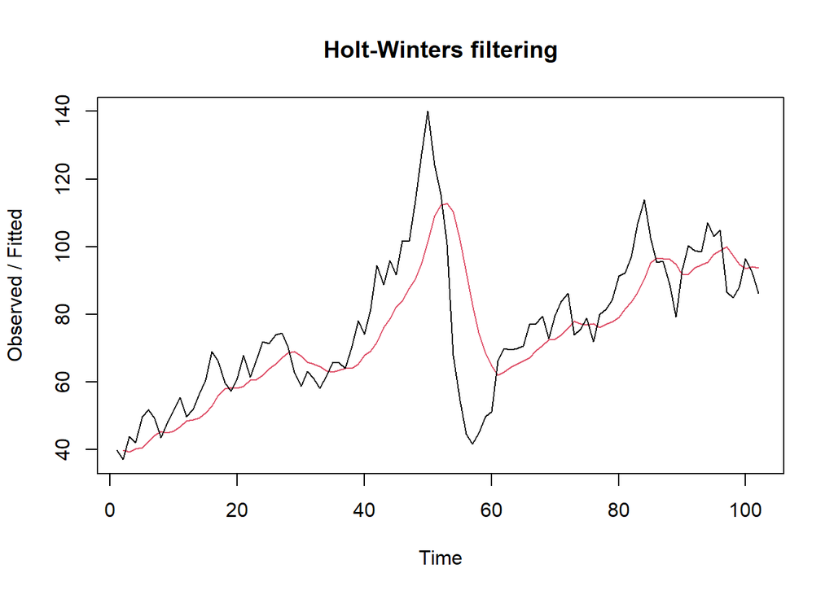

```r
#Cara 2 (fungsi Holtwinter)
ses1<- HoltWinters(train.ts, gamma = FALSE, beta = FALSE, alpha = 0.2)
plot(ses1)
```

```r
#ramalan
ramalan1<- forecast(ses1, h=26)
ramalan1
```

```
##     Point Forecast    Lo 80    Hi 80    Lo 95    Hi 95
## 103       92.21604 74.55556 109.8765 65.20666 119.2254
## 104       92.21604 74.20581 110.2263 64.67177 119.7603
## 105       92.21604 73.86273 110.5694 64.14707 120.2850
## 106       92.21604 73.52594 110.9061 63.63200 120.8001
## 107       92.21604 73.19512 111.2370 63.12605 121.3060
## 108       92.21604 72.86995 111.5621 62.62874 121.8033
## 109       92.21604 72.55016 111.8819 62.13967 122.2924
## 110       92.21604 72.23548 112.1966 61.65841 122.7737
## 111       92.21604 71.92569 112.5064 61.18462 123.2475
## 112       92.21604 71.62055 112.8115 60.71796 123.7141
## 113       92.21604 71.31987 113.1122 60.25811 124.1740
## 114       92.21604 71.02346 113.4086 59.80478 124.6273
## 115       92.21604 70.73113 113.7010 59.35771 125.0744
## 116       92.21604 70.44273 113.9894 58.91664 125.5155
## 117       92.21604 70.15810 114.2740 58.48133 125.9508
## 118       92.21604 69.87710 114.5550 58.05157 126.3805
## 119       92.21604 69.59958 114.8325 57.62715 126.8049
## 120       92.21604 69.32544 115.1067 57.20788 127.2242
## 121       92.21604 69.05453 115.3776 56.79357 127.6385
## 122       92.21604 68.78676 115.6453 56.38405 128.0480
## 123       92.21604 68.52201 115.9101 55.97915 128.4529
## 124       92.21604 68.26019 116.1719 55.57873 128.8534
## 125       92.21604 68.00120 116.4309 55.18264 129.2494
## 126       92.21604 67.74495 116.6871 54.79074 129.6413
## 127       92.21604 67.49136 116.9407 54.40290 130.0292
## 128       92.21604 67.24034 117.1917 54.01900 130.4131
```

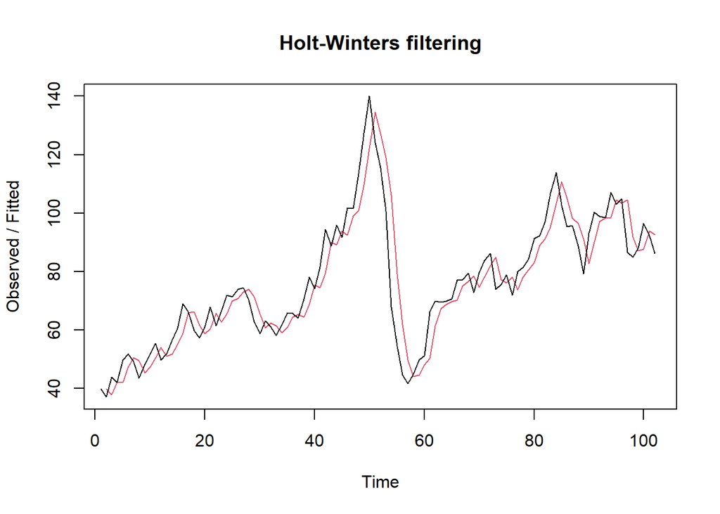

```r
ses2<- HoltWinters(train.ts, gamma = FALSE, beta = FALSE, alpha = 0.7)
plot(ses2)
```

```r
#ramalan
ramalan2<- forecast(ses2, h=26)
ramalan2
```

```
##     Point Forecast    Lo 80     Hi 80    Lo 95    Hi 95
## 103        88.1749 77.14855  99.20125 71.31155 105.0382
## 104        88.1749 74.71552 101.63427 67.59056 108.7592
## 105        88.1749 72.65945 103.69034 64.44607 111.9037
## 106        88.1749 70.84563 105.50416 61.67207 114.6777
## 107        88.1749 69.20445 107.14534 59.16210 117.1877
## 108        88.1749 67.69436 108.65543 56.85262 119.4972
## 109        88.1749 66.28822 110.06157 54.70211 121.6477
## 110        88.1749 64.96712 111.38268 52.68166 123.6681
## 111        88.1749 63.71727 112.63252 50.77019 125.5796
## 112        88.1749 62.52826 113.82153 48.95175 127.3980
## 113        88.1749 61.39199 114.95781 47.21397 129.1358
## 114        88.1749 60.30200 116.04780 45.54697 130.8028
## 115        88.1749 59.25305 117.09674 43.94276 132.4070
## 116        88.1749 58.24085 118.10895 42.39472 133.9551
## 117        88.1749 57.26176 119.08803 40.89734 135.4525
## 118        88.1749 56.31275 120.03704 39.44595 136.9038
## 119        88.1749 55.39120 120.95859 38.03657 138.3132
## 120        88.1749 54.49486 121.85493 36.66572 139.6841
## 121        88.1749 53.62176 122.72803 35.33043 141.0194
## 122        88.1749 52.77018 123.57961 34.02806 142.3217
## 123        88.1749 51.93862 124.41118 32.75629 143.5935
## 124        88.1749 51.12571 125.22409 31.51305 144.8367
## 125        88.1749 50.33026 126.01954 30.29651 146.0533
## 126        88.1749 49.55118 126.79861 29.10503 147.2448
## 127        88.1749 48.78752 127.56227 27.93710 148.4127
## 128        88.1749 48.03838 128.31141 26.79139 149.5584
```

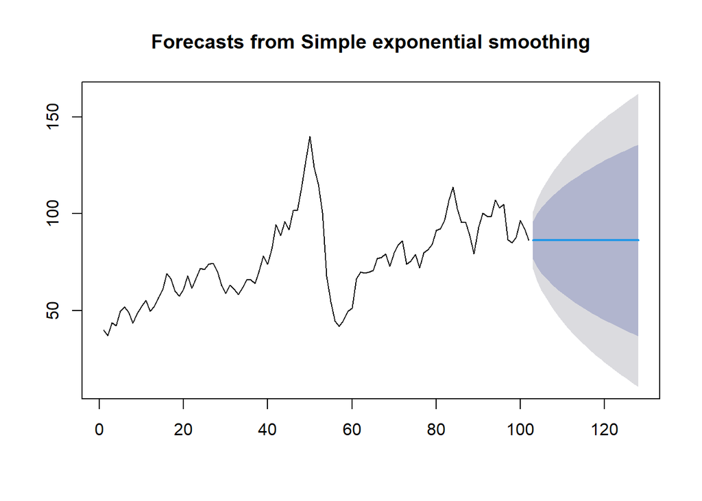

```r
#SES
ses.opt <- ses(train.ts, h = 26, alpha = NULL)
plot(ses.opt)
```

```r
ses.opt
```

```
##     Point Forecast    Lo 80     Hi 80    Lo 95    Hi 95
## 103        86.2406 76.51718  95.96401 71.36991 101.1113
## 104        86.2406 72.49029  99.99090 65.21132 107.2699
## 105        86.2406 69.40026 103.08093 60.48553 111.9957
## 106        86.2406 66.79522 105.68597 56.50146 115.9797
## 107        86.2406 64.50011 107.98108 52.99140 119.4898
## 108        86.2406 62.42517 110.05602 49.81804 122.6631
## 109        86.2406 60.51706 111.96413 46.89984 125.5814
## 110        86.2406 58.74102 113.74017 44.18363 128.2976
## 111        86.2406 57.07294 115.40825 41.63251 130.8487
## 112        86.2406 55.49522 116.98597 39.21960 133.2616
## 113        86.2406 53.99460 118.48659 36.92460 135.5566
## 114        86.2406 52.56078 119.92041 34.73176 137.7494
## 115        86.2406 51.18555 121.29564 32.62853 139.8527
## 116        86.2406 49.86228 122.61891 30.60476 141.8764
## 117        86.2406 48.58548 123.89571 28.65206 143.8291
## 118        86.2406 47.35057 125.13062 26.76344 145.7178
## 119        86.2406 46.15369 126.32750 24.93297 147.5482
## 120        86.2406 44.99152 127.48967 23.15559 149.3256
## 121        86.2406 43.86122 128.61997 21.42693 151.0543
## 122        86.2406 42.76028 129.72091 19.74319 152.7380
## 123        86.2406 41.68654 130.79465 18.10105 154.3801
## 124        86.2406 40.63808 131.84311 16.49756 155.9836
## 125        86.2406 39.61318 132.86801 14.93012 157.5511
## 126        86.2406 38.61034 133.87085 13.39640 159.0848
## 127        86.2406 37.62818 134.85302 11.89431 160.5869
## 128        86.2406 36.66547 135.81572 10.42198 162.0592
```

```r
#Lamda Optimum Holt Winter
HWopt<- HoltWinters(train.ts, gamma = FALSE, beta = FALSE,alpha = NULL)
HWopt
```

```
## Holt-Winters exponential smoothing without trend and without seasonal component.
##
## Call:
## HoltWinters(x = train.ts, alpha = NULL, beta = FALSE, gamma = FALSE)
##
## Smoothing parameters:
##  alpha: 0.9999241
##  beta : FALSE
##  gamma: FALSE
##
## Coefficients:
##       [,1]
## a 86.24045
```

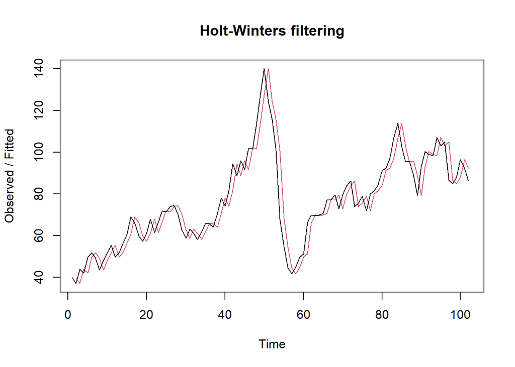

```r
plot(HWopt)
```

```r
#ramalan
ramalanopt<- forecast(HWopt, h=26)
ramalanopt
```

```
##     Point Forecast    Lo 80     Hi 80    Lo 95    Hi 95
## 103       86.24045 76.53509  95.94582 71.39738 101.0835
## 104       86.24045 72.51551  99.96539 65.24997 107.2309
## 105       86.24045 69.43112 103.04979 60.53279 111.9481
## 106       86.24045 66.83083 105.65008 56.55599 115.9249
## 107       86.24045 64.53991 107.94099 53.05234 119.4286
## 108       86.24045 62.46876 110.01214 49.88479 122.5961
## 109       86.24045 60.56414 111.91676 46.97192 125.5090
## 110       86.24045 58.79135 113.68955 44.26068 128.2202
## 111       86.24045 57.12632 115.35458 41.71423 130.7667
## 112       86.24045 55.55149 116.92942 39.30573 133.1752
## 113       86.24045 54.05362 118.42729 37.01493 135.4660
## 114       86.24045 52.62242 119.85849 34.82611 137.6548
## 115       86.24045 51.24971 121.23119 32.72673 139.7542
## 116       86.24045 49.92886 122.55205 30.70666 141.7742
## 117       86.24045 48.65439 123.82651 28.75754 143.7234
## 118       86.24045 47.42175 125.05915 26.87237 145.6085
## 119       86.24045 46.22706 126.25384 25.04525 147.4356
## 120       86.24045 45.06702 127.41388 23.27113 149.2098
## 121       86.24045 43.93879 128.54212 21.54564 150.9353
## 122       86.24045 42.83987 129.64104 19.86498 152.6159
## 123       86.24045 41.76809 130.71281 18.22585 154.2551
## 124       86.24045 40.72155 131.75935 16.62530 155.8556
## 125       86.24045 39.69853 132.78237 15.06073 157.4202
## 126       86.24045 38.69752 133.78338 13.52982 158.9511
## 127       86.24045 37.71716 134.76374 12.03048 160.4504
## 128       86.24045 36.75621 135.72469 10.56084 161.9201
```

### Akurasi Data Latih

```r
#Keakuratan Metode
#Pada data training

# SES dengan alpha = 0.2
SSE1<-ses1$SSE
MSE1<-ses1$SSE/length(train.ts)
RMSE1<-sqrt(MSE1)

akurasi1 <- matrix(c(SSE1,MSE1,RMSE1))
row.names(akurasi1)<- c("SSE", "MSE", "RMSE")
colnames(akurasi1) <- c("Akurasi lamda=0.2")
akurasi1
```

```
##      Akurasi lamda=0.2
## SSE        19668.34709
## MSE          192.82693
## RMSE          13.88621
```

```r
# SES dengan alpha = 0.7
SSE2<-ses2$SSE
MSE2<-ses2$SSE/length(train.ts)
RMSE2<-sqrt(MSE2)

akurasi2 <- matrix(c(SSE2,MSE2,RMSE2))
row.names(akurasi2)<- c("SSE", "MSE", "RMSE")
colnames(akurasi2) <- c("Akurasi lamda=0.7")
akurasi2
```

```
##      Akurasi lamda=0.7
## SSE        7449.848293
## MSE          73.037728
## RMSE          8.546211
```

```r
SSE1<-ses1$SSE
SSE1
```

```
## [1] 19668.35
```

```r
#Cara Manual
# Alpha = 0.2
fitted1<-ramalan1$fitted
sisaan1<-ramalan1$residuals
head(sisaan1)
```

```
## Time Series:
## Start = 1
## End = 6
## Frequency = 1
## [1]        NA -2.830000  4.486000  1.908800  9.047040  9.357632
```

```r
resid1<-training$price-ramalan1$fitted
head(resid1)
```

```
## Time Series:
## Start = 1
## End = 6
## Frequency = 1
## [1]        NA -2.830000  4.486000  1.908800  9.047040  9.357632
```

```r
SSE.1=sum(sisaan1[2:length(train.ts)]^2)
SSE.1
```

```
## [1] 19668.35
```

```r
MSE.1 = SSE.1/length(train.ts)
MSE.1
```

```
## [1] 192.8269
```

```r
MAPE.1 = sum(abs(sisaan1[2:length(train.ts)]/train.ts[2:length(train.ts)])*
               100)/length(train.ts)
MAPE.1
```

```
## [1] 13.76688
```

```r
akurasi.1 <- matrix(c(SSE.1,MSE.1,MAPE.1))
row.names(akurasi.1)<- c("SSE", "MSE", "MAPE")
colnames(akurasi.1) <- c("Akurasi lamda=0.2")
akurasi.1
```

```
##      Akurasi lamda=0.2
## SSE        19668.34709
## MSE          192.82693
## MAPE          13.76688
```

```r
# Alpha = 0.7
fitted2<-ramalan2$fitted
sisaan2<-ramalan2$residuals
head(sisaan2)
```

```
## Time Series:
## Start = 1
## End = 6
## Frequency = 1
## [1]        NA -2.830000  5.901000  0.090300  7.547090  4.384127
```

```r
resid2<-training$price-ramalan2$fitted
head(resid2)
```

```
## Time Series:
## Start = 1
## End = 6
## Frequency = 1
## [1]        NA -2.830000  5.901000  0.090300  7.547090  4.384127
```

```r
SSE.2=sum(sisaan2[2:length(train.ts)]^2)
SSE.2
```

```
## [1] 7449.848
```

```r
MSE.2 = SSE.2/length(train.ts)
MSE.2
```

```
## [1] 73.03773
```

```r
MAPE.2 = sum(abs(sisaan2[2:length(train.ts)]/train.ts[2:length(train.ts)])*
               100)/length(train.ts)
MAPE.2
```

```
## [1] 8.48987
```

```r
akurasi.2 <- matrix(c(SSE.2,MSE.2,MAPE.2))
row.names(akurasi.2)<- c("SSE", "MSE", "MAPE")
colnames(akurasi.2) <- c("Akurasi lamda=0.7")
akurasi.2
```

```
##      Akurasi lamda=0.7
## SSE         7449.84829
## MSE           73.03773
## MAPE           8.48987
```

Akurasi data latih SES Lamda 0.2 SSE= 19668.34709 MSE= 192.82693 RMSE= 13.88621 MAPE= 13.76688

Lamda 0.7 SSE= 7449.84829 MSE= 73.03773 RMSE= 8.546211 MAPE= 8.48987

### Akurasi Data Uji

```r
# jumlah observasi uji
n_test <- nrow(testing)

# error (ramalan - aktual), samakan panjang dan tipe numeric
e1   <- as.numeric(ramalan1$mean)[1:n_test] - as.numeric(testing$price)
e2   <- as.numeric(ramalan2$mean)[1:n_test] - as.numeric(testing$price)
eopt <- as.numeric(ramalanopt$mean)[1:n_test] - as.numeric(testing$price)

# SSE / MSE / RMSE untuk masing-masing model (abaikan NA)
SSEtesting1  <- sum(e1^2,  na.rm = TRUE)
MSEtesting1  <- mean(e1^2, na.rm = TRUE)
RMSEtesting1 <- sqrt(MSEtesting1)

SSEtesting2  <- sum(e2^2,  na.rm = TRUE)
MSEtesting2  <- mean(e2^2, na.rm = TRUE)
RMSEtesting2 <- sqrt(MSEtesting2)

SSEtestingopt  <- sum(eopt^2,  na.rm = TRUE)
MSEtestingopt  <- mean(eopt^2, na.rm = TRUE)
RMSEtestingopt <- sqrt(MSEtestingopt)

# Tabel ringkas
akurasitesting_SSE <- matrix(c(SSEtesting1, SSEtesting2, SSEtestingopt),
                             nrow = 3,
                             dimnames = list(c("SSE1","SSE2","SSEopt"), "Nilai"))
akurasitesting_MSE <- matrix(c(MSEtesting1, MSEtesting2, MSEtestingopt),
                             nrow = 3,
                             dimnames = list(c("MSE1","MSE2","MSEopt"), "Nilai"))
akurasitesting_RMSE <- matrix(c(RMSEtesting1, RMSEtesting2, RMSEtestingopt),
                              nrow = 3,
                              dimnames = list(c("RMSE1","RMSE2","RMSEopt"), "Nilai"))

akurasitesting_SSE
```

```
##           Nilai
## SSE1   3591.347
## SSE2   4413.056
## SSEopt 5106.943
```

```r
akurasitesting_MSE
```

```
##           Nilai
## MSE1   138.1287
## MSE2   169.7329
## MSEopt 196.4209
```

```r
akurasitesting_RMSE
```

```
##            Nilai
## RMSE1   11.75282
## RMSE2   13.02816
## RMSEopt 14.01502
```

```r
accuracy(ramalan1, testing$price)
```

```
##                    ME     RMSE      MAE        MPE     MAPE     MASE      ACF1
## Training set 2.590893 13.95479 9.859389  0.9069846 13.90319 1.699779 0.8335104
## Test set     1.889725 11.75282 8.186521 -0.1474141 10.06554 1.411373        NA
```

```r
accuracy(ramalan2, testing$price)
```

```
##                     ME      RMSE       MAE       MPE      MAPE     MASE
## Training set 0.6830961  8.588415  6.369834 0.2880533  8.573928 1.098172
## Test set     5.9308729 13.028158 10.897387 4.2413074 12.572039 1.878732
##                   ACF1
## Training set 0.5241165
## Test set            NA
```

```r
accuracy(ramalanopt, testing$price)
```

```
##                     ME      RMSE       MAE       MPE      MAPE     MASE
## Training set 0.4590492  7.549522  5.800474 0.2846957  7.746917 1.000013
## Test set     7.8653177 14.015023 12.385422 6.3421310 13.983818 2.135272
##                   ACF1
## Training set 0.2550845
## Test set            NA
```

Akurasi data uji SES: ramalan1: ME RMSE MAE MPE MAPE MASE ACF1 Training set 2.590893 13.95479 9.859389 0.9069846 13.90319 1.699779 0.8335104 Test set 1.889725 11.75282 8.186521 -0.1474141 10.06554 1.411373 NA

ramalan2: ME RMSE MAE MPE MAPE MASE ACF1 Training set 0.6830961 8.588415 6.369834 0.2880533 8.573928 1.098172 0.5241165 Test set 5.9308729 13.028158 10.897387 4.2413074 12.572039 1.878732 NA

ramalanopt: ME RMSE MAE MPE MAPE MASE ACF1 Training set 0.4590492 7.549522 5.800474 0.2846957 7.746917 1.000013 0.2550845 Test set 7.8653177 14.015023 12.385422 6.3421310 13.983818 2.135272 NA

## Double Exponential Smoothing (DES)

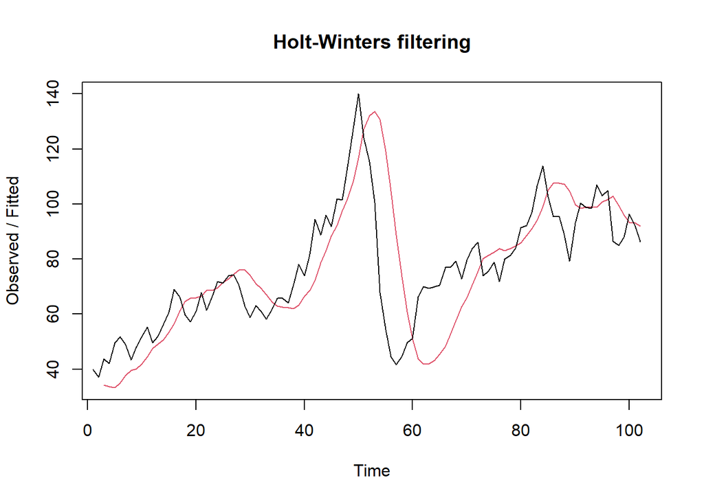

```r
#Lamda=0.2 dan gamma=0.2
des.1<- HoltWinters(train.ts, gamma = FALSE, beta = 0.2, alpha = 0.2)
plot(des.1)
```

```r
#ramalan
ramalandes1<- forecast(des.1, h=26)
ramalandes1
```

```
##     Point Forecast      Lo 80    Hi 80      Lo 95    Hi 95
## 103       89.72089  67.560944 111.8808  55.830177 123.6116
## 104       88.58337  65.794156 111.3726  53.730273 123.4365
## 105       87.44586  63.827056 111.0647  51.324017 123.5677
## 106       86.30834  61.647996 110.9687  48.593597 124.0231
## 107       85.17083  59.252214 111.0894  45.531729 124.8099
## 108       84.03331  56.640892 111.4257  42.140221 125.9264
## 109       82.89579  53.819783 111.9718  38.427872 127.3637
## 110       81.75828  50.797733 112.7188  34.408210 129.1083
## 111       80.62076  47.585344 113.6562  30.097449 131.1441
## 112       79.48325  44.193924 114.7726  25.512884 133.4536
## 113       78.34573  40.634737 116.0567  20.671742 136.0197
## 114       77.20821  36.918532 117.4979  15.590462 138.8260
## 115       76.07070  33.055281 119.0861  10.284294 141.8571
## 116       74.93318  29.054066 120.8123   4.767128 145.0992
## 117       73.79567  24.923062 122.6683  -0.948532 148.5399
## 118       72.65815  20.669576 124.6467  -6.851514 152.1678
## 119       71.52064  16.300112 126.7412 -12.931867 155.9731
## 120       70.38312  11.820456 128.9458 -19.180745 159.9470
## 121       69.24560   7.235754 131.2555 -25.590278 164.0815
## 122       68.10809   2.550591 133.6656 -32.153451 168.3696
## 123       66.97057  -2.230935 136.1721 -38.864000 172.8051
## 124       65.83306  -7.105155 138.7713 -45.716311 177.3824
## 125       64.69554 -12.068766 141.4598 -52.705335 182.0964
## 126       63.55802 -17.118791 144.2348 -59.826516 186.9426
## 127       62.42051 -22.252528 147.0935 -67.075726 191.9167
## 128       61.28299 -27.467524 150.0335 -74.449209 197.0152
```

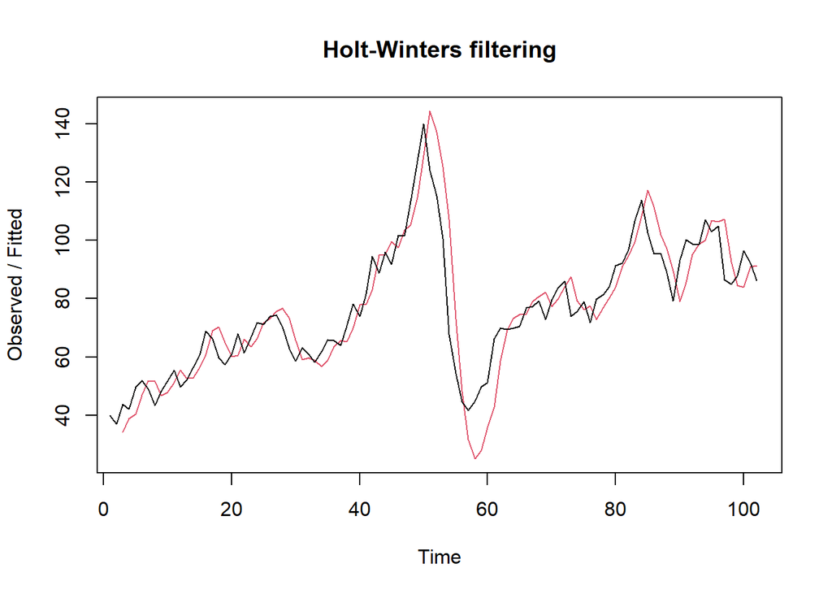

```r
#Lamda=0.6 dan gamma=0.3
des.2<- HoltWinters(train.ts, gamma = FALSE, beta = 0.3, alpha = 0.6)
plot(des.2)
```

```r
#ramalan
ramalandes2<- forecast(des.2, h=26)
ramalandes2
```

```
##     Point Forecast       Lo 80     Hi 80       Lo 95    Hi 95
## 103       87.03436   74.430103  99.63862   67.757811 106.3109
## 104       85.79310   69.808031 101.77816   61.346049 110.2401
## 105       84.55183   64.503524 104.60013   53.890593 115.2131
## 106       83.31056   58.644824 107.97629   45.587572 121.0335
## 107       82.06929   52.316829 111.82175   36.566826 127.5718
## 108       80.82802   45.576631 116.07941   26.915672 134.7404
## 109       79.58675   38.464402 120.70911   16.695543 142.4780
## 110       78.34549   31.009819 125.68116    5.951830 150.7391
## 111       77.10422   23.235787 130.97265   -5.280438 159.4889
## 112       75.86295   15.160645 136.56526  -16.973215 168.6991
## 113       74.62168    6.799518 142.44385  -29.103367 178.3467
## 114       73.38041   -1.834815 148.59564  -41.651353 188.4122
## 115       72.13915  -10.731348 155.00964  -54.600339 198.8786
## 116       70.89788  -19.880450 161.67621  -67.935595 209.7314
## 117       69.65661  -29.273585 168.58681  -81.644067 220.9573
## 118       68.41534  -38.903106 175.73379  -95.714061 232.5447
## 119       67.17407  -48.762101 183.11025 -110.135005 244.4832
## 120       65.93281  -58.844277 190.70989 -124.897276 256.7629
## 121       64.69154  -69.143866 198.52694 -139.992049 269.3751
## 122       63.45027  -79.655550 206.55609 -155.411195 282.3117
## 123       62.20900  -90.374405 214.79241 -171.147182 295.5652
## 124       60.96773 -101.295853 223.23132 -187.193007 309.1285
## 125       59.72647 -112.415615 231.86855 -203.542129 322.9951
## 126       58.48520 -123.729689 240.70009 -220.188423 337.1588
## 127       57.24393 -135.234308 249.72217 -237.126133 351.6140
## 128       56.00266 -146.925928 258.93125 -254.349835 366.3552
```

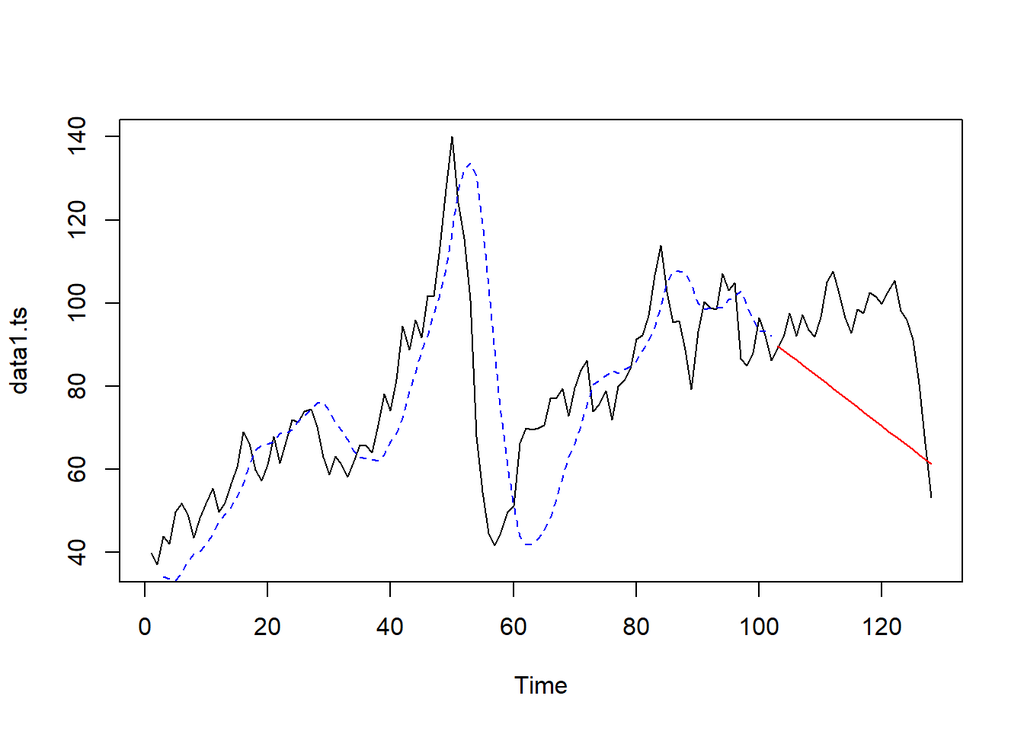

```r
plot(data1.ts)
lines(des.1$fitted[,1], lty=2, col="blue")
lines(ramalandes1$mean, col="red")
```

```r
#Lamda dan gamma optimum
des.opt<- HoltWinters(train.ts, gamma = FALSE)
des.opt
```

```
## Holt-Winters exponential smoothing with trend and without seasonal component.
##
## Call:
## HoltWinters(x = train.ts, gamma = FALSE)
##
## Smoothing parameters:
##  alpha: 1
##  beta : 0.0377211
##  gamma: FALSE
##
## Coefficients:
##          [,1]
## a 86.24000000
## b -0.06841025
```

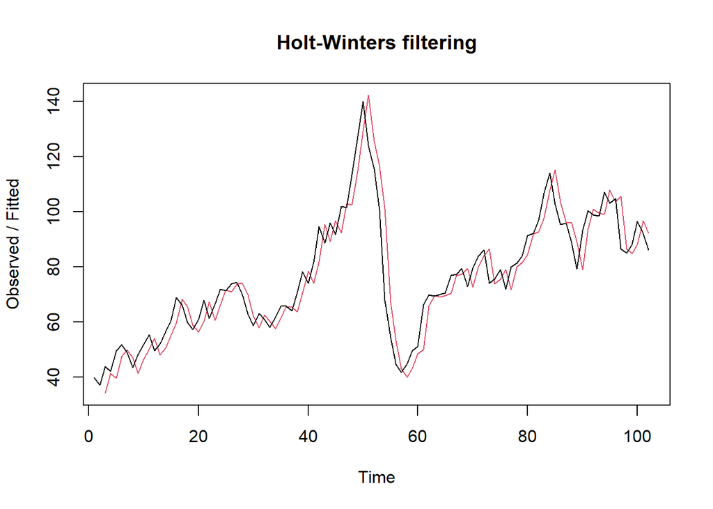

```r
plot(des.opt)
```

```r
#ramalan
ramalandesopt<- forecast(des.opt, h=26)
ramalandesopt
```

```
##     Point Forecast     Lo 80     Hi 80      Lo 95    Hi 95
## 103       86.17159 76.160594  96.18259  70.861093 101.4821
## 104       86.10318 71.676001 100.53036  64.038713 108.1676
## 105       86.03477 68.033226 104.03631  58.503784 113.5658
## 106       85.96636 64.794645 107.13807  53.587016 118.3457
## 107       85.89795 61.794289 110.00161  49.034582 122.7613
## 108       85.82954 58.948772 112.71030  44.718955 126.9401
## 109       85.76113 56.209577 115.31268  40.565931 130.9563
## 110       85.69272 53.545752 117.83968  36.528176 134.8573
## 111       85.62431 50.936262 120.31235  32.573520 138.6751
## 112       85.55590 48.366133 122.74566  28.679061 142.4327
## 113       85.48749 45.824318 125.15066  24.827905 146.1471
## 114       85.41908 43.302444 127.53571  21.007246 149.8309
## 115       85.35067 40.794015 129.90732  17.207148 153.4942
## 116       85.28226 38.293901 132.27061  13.419769 157.1447
## 117       85.21385 35.797990 134.62970   9.638816 160.7889
## 118       85.14544 33.302939 136.98793   5.859179 164.4317
## 119       85.07703 30.806006 139.34804   2.076664 168.0774
## 120       85.00862 28.304918 141.71231  -1.712206 171.7294
## 121       84.94021 25.797777 144.08263  -5.510334 175.3907
## 122       84.87179 23.282985 146.46060  -9.320161 179.0638
## 123       84.80338 20.759194 148.84758 -13.143753 182.7505
## 124       84.73497 18.225255 151.24469 -16.982864 186.4528
## 125       84.66656 15.680190 153.65294 -20.838991 190.1721
## 126       84.59815 13.123160 156.07315 -24.713417 193.9097
## 127       84.52974 10.553445 158.50604 -28.607243 197.6667
## 128       84.46133  7.970425 160.95224 -32.521416 201.4441
```

### Akurasi data latih

```r
#Akurasi Data Training
ssedes.train1<-des.1$SSE
msedes.train1<-ssedes.train1/length(train.ts)
sisaandes1<-ramalandes1$residuals
head(sisaandes1)
```

```
## Time Series:
## Start = 1
## End = 6
## Frequency = 1
## [1]       NA       NA  9.58000  8.43080 16.37421 16.67397
```

```r
mapedes.train1 <- sum(abs(sisaandes1[3:length(train.ts)]/train.ts[3:length(train.ts)])
                      *100)/length(train.ts)

akurasides.1 <- matrix(c(ssedes.train1,msedes.train1,mapedes.train1))
row.names(akurasides.1)<- c("SSE", "MSE", "MAPE")
colnames(akurasides.1) <- c("Akurasi lamda=0.2 dan gamma=0.2")
akurasides.1
```

```
##      Akurasi lamda=0.2 dan gamma=0.2
## SSE                      29618.49740
## MSE                        290.37743
## MAPE                        17.31606
```

```r
ssedes.train2<-des.2$SSE
msedes.train2<-ssedes.train2/length(train.ts)
sisaandes2<-ramalandes2$residuals
head(sisaandes2)
```

```
## Time Series:
## Start = 1
## End = 6
## Frequency = 1
## [1]       NA       NA 9.580000 3.257600 9.342272 4.694532
```

```r
mapedes.train2 <- sum(abs(sisaandes2[3:length(train.ts)]/train.ts[3:length(train.ts)])
                      *100)/length(train.ts)

akurasides.2 <- matrix(c(ssedes.train2,msedes.train2,mapedes.train2))
row.names(akurasides.2)<- c("SSE", "MSE", "MAPE")
colnames(akurasides.2) <- c("Akurasi lamda=0.6 dan gamma=0.3")
akurasides.2
```

```
##      Akurasi lamda=0.6 dan gamma=0.3
## SSE                      9577.079154
## MSE                        93.892933
## MAPE                        9.844073
```

### Akurasi data uji

```r
#Akurasi Data Testing
selisihdes1<-ramalandes1$mean-testing$price
selisihdes1
```

```
## Time Series:
## Start = 103
## End = 128
## Frequency = 1
##  [1]   0.8108902  -3.2366258 -10.0441417  -5.7416577 -12.0591736  -9.4266896
##  [7]  -9.0742055 -14.8017214 -24.4092374 -28.1667533 -23.9842693 -19.1717852
## [13] -16.6493012 -23.4868171 -23.6943330 -29.9318490 -30.0593649 -29.3568809
## [19] -33.4643968 -37.2619128 -31.1994287 -30.1269447 -26.4644606 -16.9819765
## [25]  -3.7294925   8.0129916
```

```r
SSEtestingdes1<-sum(selisihdes1^2)
MSEtestingdes1<-SSEtestingdes1/length(testing$price)
MAPEtestingdes1<-sum(abs(selisihdes1/testing$price)*100)/length(testing$price)

selisihdes2<-ramalandes2$mean-testing$price
selisihdes2
```

```
## Time Series:
## Start = 103
## End = 128
## Frequency = 1
##  [1]  -1.875637  -6.026905 -12.938173  -8.739441 -15.160709 -12.631977
##  [7] -12.383245 -18.214513 -27.925781 -31.787049 -27.708317 -22.999585
## [13] -20.580853 -27.522121 -27.833389 -34.174657 -34.405925 -33.807193
## [19] -38.018462 -41.919730 -35.960998 -34.992266 -31.433534 -22.054802
## [25]  -8.906070   2.732662
```

```r
SSEtestingdes2<-sum(selisihdes2^2)
MSEtestingdes2<-SSEtestingdes2/length(testing$price)
MAPEtestingdes2<-sum(abs(selisihdes2/testing$price)*100)/length(testing$price)

selisihdesopt<-ramalandesopt$mean-testing$price
selisihdesopt
```

```
## Time Series:
## Start = 103
## End = 128
## Frequency = 1
##  [1]  -2.738410  -5.716821 -11.455231  -6.083641 -11.332051  -7.630462
##  [7]  -6.208872 -10.867282 -19.405692 -22.094103 -16.842513 -10.960923
## [13]  -7.369333 -13.137744 -12.276154 -17.444564 -16.502974 -14.731385
## [19] -17.769795 -20.498205 -13.366615 -11.225026  -6.493436   4.058154
## [25]  18.379744  31.191333
```

```r
SSEtestingdesopt<-sum(selisihdesopt^2)
MSEtestingdesopt<-SSEtestingdesopt/length(testing$price)
MAPEtestingdesopt<-sum(abs(selisihdesopt/testing$price)*100)/length(testing$price)

akurasitestingdes <-
  matrix(c(SSEtestingdes1,MSEtestingdes1,MAPEtestingdes1,SSEtestingdes2,MSEtestingdes2,
           MAPEtestingdes2,SSEtestingdesopt,MSEtestingdesopt,MAPEtestingdesopt),
         nrow=3,ncol=3)
row.names(akurasitestingdes)<- c("SSE", "MSE", "MAPE")
colnames(akurasitestingdes) <- c("des ske1","des ske2","des opt")
akurasitestingdes
```

```
##         des ske1    des ske2    des opt
## SSE  12520.46658 16977.06389 5401.48670
## MSE    481.55641   652.96400  207.74949
## MAPE    19.90924    23.46445   14.41534
```

```r
MSEfull <-
  matrix(c(MSEtesting1,MSEtesting2,MSEtestingopt,MSEtestingdes1,MSEtestingdes2,
           MSEtestingdesopt),nrow=3,ncol=2)
row.names(MSEfull)<- c("ske 1", "ske 2", "ske opt")
colnames(MSEfull) <- c("ses","des")
MSEfull
```

```
##              ses      des
## ske 1   138.1287 481.5564
## ske 2   169.7329 652.9640
## ske opt 196.4209 207.7495
```

# Kesimpulan

Kesimpulan Model Terbaik

Berdasarkan nilai MAPE pada data uji, yang mencerminkan persentase kesalahan prediksi relatif terhadap nilai aktual, peringkat akurasi model dari yang terbaik hingga terburuk adalah sebagai berikut:

### 1. DMA (Double Moving Average)

MAPE = 9.79% Model ini memberikan prediksi dengan kesalahan relatif paling kecil dibanding model lainnya, sehingga secara persentase prediksi mendekati nilai aktual dengan baik.

### 2. SES (Single Exponential Smoothing, Ramalan1)

MAPE = 10.07%

Meskipun SSE sedikit lebih rendah dari DMA, dari perspektif persentase kesalahan, model ini berada di peringkat kedua. Prediksi cukup akurat dan stabil.

### 3. SMA (Simple Moving Average)

MAPE = 10.86% Model ini relatif baik, tetapi sedikit lebih tinggi kesalahannya dibanding SES dan DMA.

### 4. DES (Double Exponential Smoothing, Optimized)

MAPE = 14.42% Model ini memiliki kesalahan persentase tertinggi pada data uji, menunjukkan kemungkinan overfitting pada data latih dan kurang mampu memprediksi data baru dengan akurat.